# Original Study: Data Cleaning

## MOUSETRAP ANALYSIS

```r
#tibble into data frame for mousetrap object
head(as.data.frame(xdata_animal))
```

```
##   submission_id   RT correct correctness endTime mousetrackingDuration
## 1          2141 1778 Reptile     Correct 1.6e+12                  1531
## 2          2141 1338    Fish     Correct 1.6e+12                  1191
## 3          2141 1692 Reptile     Correct 1.6e+12                  1641
## 4          2141 1323    Bird     Correct 1.6e+12                  1172
## 5          2141 1662    Fish     Correct 1.6e+12                  1502
## 6          2141 1958  Mammal     Correct 1.6e+12                  1679
##   mousetrackingStartTime
## 1                1.6e+12
## 2                1.6e+12
## 3                1.6e+12
## 4                1.6e+12
## 5                1.6e+12
## 6                1.6e+12
##                                                                                                                                                                                                                                                                                                          …
```

[output cut: 41 more lines]

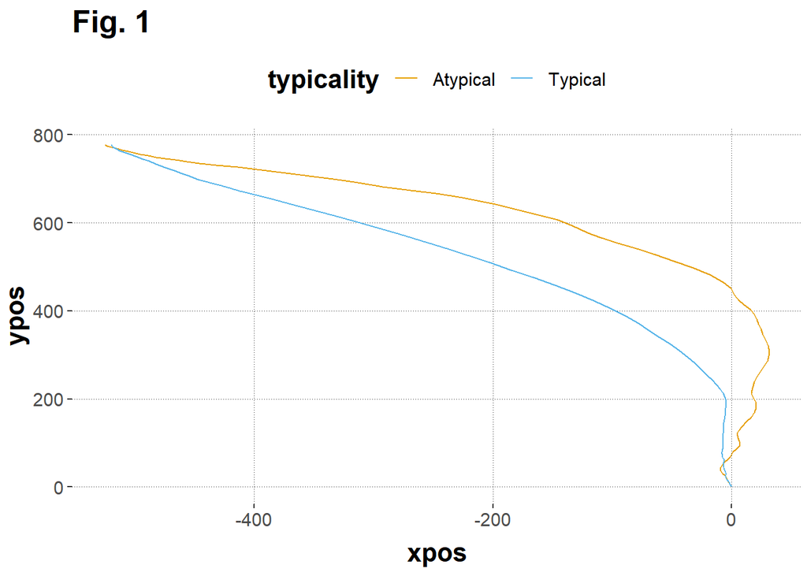

```r
##TRAJECTORY PREPROCESSING

#creating mousetrap object for further anaylsis
mt_data_animal <- mt_import_mousetrap(xdata_animal)

#all trajectories are remapped to the left
mt_data_animal <- mt_remap_symmetric(mt_data_animal)

#setting the starting point of the trajectories equally
mt_data_animal <- mt_align_start(mt_data_animal, start=c(0,0))

mt_data_animal <- mt_derivatives(mt_data_animal)

#important for later creating MAD and AUC values
mt_data_animal <- mt_measures(mt_data_animal)

#time-normalizing trajectories
mt_data_animal <- mt_time_normalize(mt_data_animal)


#plot aggregated time-normalized trajectories
mt_plot_aggregate(mt_data_animal, use="tn_trajectories", x="xpos", y="ypos", color="typicality",
subject_id="submission_id")+
    ggtitle("Fig. 1")
```

Fig. 1: Display of over all trials avaraged trajactory for each trial type. All trajectories have been flipped to the left. Starting and end point was set equall over all trajectories of each trail type.

# AGGREGATE TRAJECTORY CURVATURE

```r
#aggregating maximum absolut deviation (MAD) values for analysis
agg_mad_animal <- mt_aggregate_per_subject(mt_data_animal,
use_variables="MAD", use2_variables="typicality",
subject_id="submission_id")

agg_auc_animal <- mt_aggregate_per_subject(mt_data_animal,
use_variables="AUC", use2_variables="typicality",
subject_id="submission_id")
```

# CLUSTER AGGREGATION & PROTOTYPE CLASSIFICATION

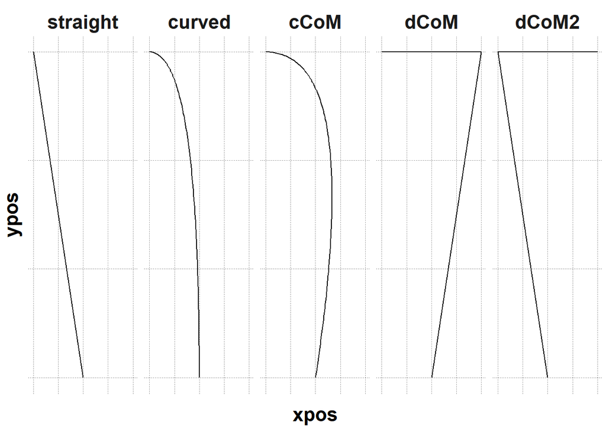

```r
#Spatialize trajectories
mt_data_animal <- mt_spatialize(mt_data_animal)

#Cluster trajectories
mt_data_animal <- mt_cluster(mt_data_animal, use = "sp_trajectories")

mt_plot(mt_prototypes,facet_col="mt_id",only_ggplot = TRUE)+
  geom_path()+
  facet_grid(cols = vars(factor(mt_id,levels=rownames(mt_prototypes))))+
  theme(axis.text=ggplot2::element_blank(),axis.ticks=ggplot2::element_blank())
```

```r
mt_data_animal <- mt_map(mt_data_animal,prototypes = mt_prototypes,
  save_as = "measures", grouping_variables = "typicality")
mt_data_animal$data$prototype_label <- mt_data_animal$measures$prototype_label

prototype_percentages <- mt_data_animal$data %>%
  group_by(typicality,prototype_label) %>%
  summarise(n=n()) %>%
  mutate(Percent=paste(round(100*n/sum(n)),"%",sep=""))
```

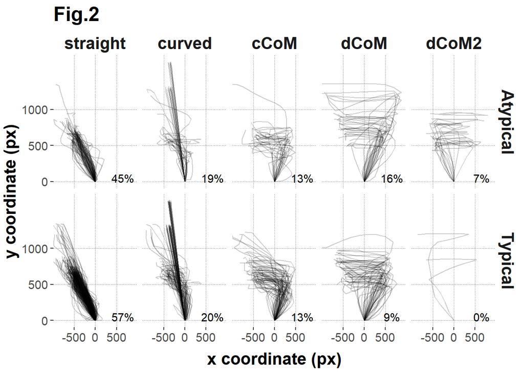

```r
mt_plot(mt_data_animal, use = "sp_trajectories",
  x = "xpos", y = "ypos", facet_col = "prototype_label", facet_row="typicality",alpha=.2)+
  xlab("x coordinate (px)") + ylab("y coordinate (px)")+
  geom_text(data=prototype_percentages,aes(label=Percent),x=650,y=50)+
  scale_y_continuous(breaks=c(0,500,1000))+
  coord_cartesian(xlim=c(-900,900))+
   ggtitle("Fig.2")
```

Fig. 2: The plot shows the percentages of trajectories for each trial type, which are assigned to the respective trajectory prototypes.

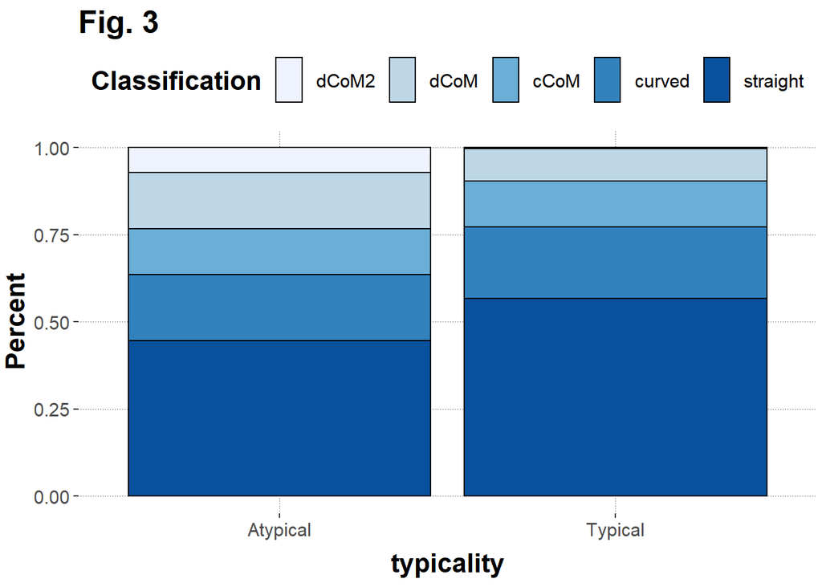

```r
rel_freq_agg <- mt_data_animal$data %>%
  group_by(typicality,prototype_label) %>%
  summarise(n=n()) %>%
  mutate(Percent=n/sum(n))

ggplot(rel_freq_agg,aes(x=typicality,y=Percent,fill=forcats::fct_rev(prototype_label)))+
  geom_bar(stat="identity",color="black")+
  scale_fill_brewer(type="seq",name="Classification")+
  facet_grid()+
   ggtitle("Fig. 3")
```

Fig. 3: The plot shows the percentages of trajectories for each trial type, which are assigned to the respective trajectory prototypes.